# Home Work 7 - Data Analysis

Shervin Hakimi

4/29/2018

## Question 1:

[figure not shown]

```r
#----------------
#We will first load the necessary libraries:
library(ggplot2)
library(corrplot)
library(onehot)
library(dplyr)
#----------------
#HW 07:
#Question1:

#Readcing data:
murder_suicide = read.csv("/Users/shervin/Desktop/Data Analysis/HW7/data 2/murder_suicide.csv")


#----------------
# Columns which are not redundant:
not.redundant = c("Age",
                  "ResidentStatus",
                  "Education2003Revision",
                  "MonthOfDeath",
                  "Sex",
                  "AgeType",
                  "PlaceOfDeathAndDecedentsStatus",
                  "MaritalStatus",
                  "DayOfWeekOfDeath",
                  "InjuryAtWork",
                  "MannerOfDeath",
                  "MethodOfDisposition",
                  "Autopsy",
                  "ActivityCode",
                  "PlaceOfInjury",
                  "Icd10Code",
                  "NumberOfEntityAxisConditions",
                  "NumberOfRecordAxisConditions",
                  "Race"
)

#----------------
#Removing redundants and turning factors to integers
#We will give every factor a binary with the onehot package to see their influence:
murder_suicide = murder_suicide[,not.redundant]
murder_suicide %>%
  filter(Education2003Revision!=9,
         PlaceOfInjury!=99,
         PlaceOfDeathAndDecedentsStatus!=9,
         MaritalStatus!="U",
         InjuryAtWork!="U",
         DayOfWeekOfDeath!=9,
         Autopsy!="U", ActivityCode!=99,
         PlaceOfInjury!=9) -> murder_suicide
#----------------
#Changing to factors thos that are sort of factors:
murder_suicide$Sex <- factor(murder_suicide$Sex)
murder_suicide$MaritalStatus <- factor(murder_suicide$MaritalStatus)
murder_suicide$InjuryAtWork <- factor(murder_suicide$InjuryAtWork)
murder_suicide$MethodOfDisposition <- factor(murder_suicide$MethodOfDisposition)
murder_suicide$Autopsy <- factor(murder_suicide$Autopsy)
murder_suicide$PlaceOfInjury <- factor(murder_suicide$PlaceOfInjury)
murder_suicide$Icd10Code <-factor(murder_suicide$Icd10Code)
murder_suicide$ResidentStatus <- factor(murder_suicide$ResidentStatus)
murder_suicide$Education2003Revision <- factor(murder_suicide$Education2003Revision)
murder_suicide$PlaceOfDeathAndDecedentsStatus <- factor(murder_suicide$PlaceOfDeathAndDecedentsStatus)
murder_suicide$Race <-factor(murder_suicide$Race)
murder_suicide$MonthOfDeath <-factor(murder_suicide$MonthOfDeath)
murder_suicide$DayOfWeekOfDeath <-factor(murder_suicide$DayOfWeekOfDeath)
#----------------
#Using onehot to make the binaries:
temp = onehot(murder_suicide , stringsAsFactors = TRUE, max_levels = 10000)
murder_suicide_levels = as.data.frame(predict(temp,murder_suicide))
#----------------
#correlation Matrix:
correlation_ms = cor(murder_suicide_levels)

#----------------
#Plotting Corrleation Matrix:
corrplot(correlation_ms, method="circle")
```

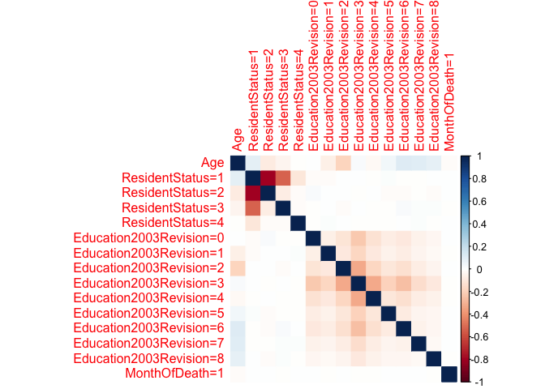

```r
#Because it is so big we will first show the first 15:
corrplot(correlation_ms[1:15,1:15], method="color")
```

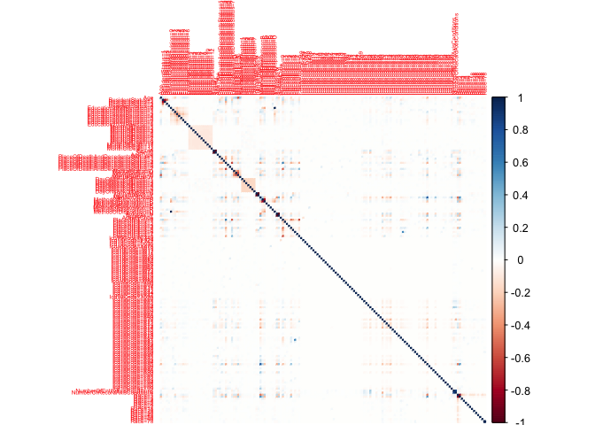

```r
#All others:
corrplot(correlation_ms, method="color",tl.cex = 0.4)
```

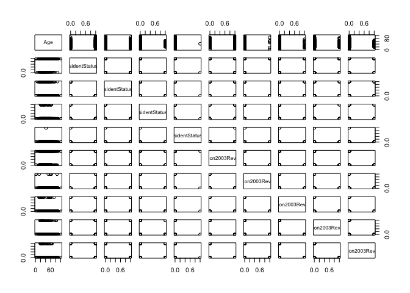

```r
#----------------
#plotting the scatter plot:
plot(murder_suicide_levels[1:1000,1:10])
```

```r
#----------------
```

We see that by making the factors as seperate columns we can easily see some significant correlations between some of the variables.

## Question 2:

We will use the Kruskall Wallis test. Because we can’t assume any distribution, therefore we have to use a non-parametric test. Between our tests Kruskall Wallis can be a good test because we have more than two states.  
As we can see all of variables have a lower `p-value` than `0.05` and therefore our assumption that these variables have no effect on death or suicide is not correct in all of these cases

```r
#----------------
#We will first load the necessary libraries:
library(ggplot2)
library(corrplot)
#----------------
#HW 07:
#Question 2:

#Readcing data:
murder_suicide = read.csv("/Users/shervin/Desktop/Data Analysis/HW7/data 2/murder_suicide.csv")

#----------------
# Columns which are not redundant:
not.redundant = c("Age",
                  "ResidentStatus",
                  "Education2003Revision",
                  "MonthOfDeath",
                  "Sex",
                  "AgeType",
                  "PlaceOfDeathAndDecedentsStatus",
                  "MaritalStatus",
                  "DayOfWeekOfDeath",
                  "InjuryAtWork",
                  "MannerOfDeath",
                  "MethodOfDisposition",
                  "Autopsy",
                  "ActivityCode",
                  "PlaceOfInjury",
                  "Icd10Code",
                  "NumberOfEntityAxisConditions",
                  "NumberOfRecordAxisConditions",
                  "Race"
)

#----------------
#Removing redundants and turning factors to integers:
murder_suicide = murder_suicide[,not.redundant]
murder_suicide_int = as.data.frame(lapply(murder_suicide,as.numeric))

murder_suicide_int %>%
  mutate(Suicide = (MannerOfDeath==2) ) ->murder_suicide_int

murder_suicide_int$Suicide <- 1*murder_suicide_int$Suicide
#----------------
#Finding P-values:

#  Age - Manner of Death

kruskal.test( Suicide ~ Age,
              data = murder_suicide_int)
```

```
##
##  Kruskal-Wallis rank sum test
##
## data:  Suicide by Age
## Kruskal-Wallis chi-squared = 6899.7, df = 103, p-value < 2.2e-16
```

```r
#  Sex - Manner of Death
kruskal.test( Suicide ~ Sex,
              data = murder_suicide_int)
```

```
##
##  Kruskal-Wallis rank sum test
##
## data:  Suicide by Sex
## Kruskal-Wallis chi-squared = 24.151, df = 1, p-value = 8.908e-07
```

```r
#  Education - Manner of Death
kruskal.test( Suicide ~ Education2003Revision,
              data = murder_suicide_int)
```

```
##
##  Kruskal-Wallis rank sum test
##
## data:  Suicide by Education2003Revision
## Kruskal-Wallis chi-squared = 3572.9, df = 9, p-value < 2.2e-16
```

```r
#  Race - Manner of Death
kruskal.test( Suicide ~ Race,
              data = murder_suicide_int)
```

```
##
##  Kruskal-Wallis rank sum test
##
## data:  Suicide by Race
## Kruskal-Wallis chi-squared = 15338, df = 13, p-value < 2.2e-16
```

```r
#  Disposition - Manner of Death MethodOfDisposition
kruskal.test( Suicide ~ MethodOfDisposition,
              data = murder_suicide_int)
```

```
##
##  Kruskal-Wallis rank sum test
##
## data:  Suicide by MethodOfDisposition
## Kruskal-Wallis chi-squared = 4460.3, df = 6, p-value < 2.2e-16
```

```r
#----------------
```

## Question 3:

For our first model we will use all the given variables. We will check the`p-value`s to see which of these variables have an impact. In our next model we will use some variables that were more essential. Again we will check the `p-value`s and take the most significant variables. From these variables we build our final model with the most significant variables.

```r
#HW 07:
#Question 3:
library(boot)
library(dplyr)
#Readcing data:

#----------------
# Columns which are not redundant:
not.redundant = c("Age",
                  "ResidentStatus",
                  "Education2003Revision",
                  "MonthOfDeath",
                  "Sex",
                  "AgeType",
                  "PlaceOfDeathAndDecedentsStatus",
                  "MaritalStatus",
                  "DayOfWeekOfDeath",
                  "InjuryAtWork",
                  "MannerOfDeath",
                  "MethodOfDisposition",
                  "Autopsy",
                  "ActivityCode",
                  "PlaceOfInjury",
                  "Icd10Code",
                  "NumberOfEntityAxisConditions",
                  "NumberOfRecordAxisConditions",
                  "Race"
)

#----------------
#Removing redundants and turning factors to integers:
murder_suicide = murder_suicide[,not.redundant]
murder_suicide_int = as.data.frame(lapply(murder_suicide,as.numeric))


murder_suicide_int$Sex <- factor(murder_suicide_int$Sex)
murder_suicide_int$MaritalStatus <- factor(murder_suicide_int$MaritalStatus)
murder_suicide_int$InjuryAtWork <- factor(murder_suicide_int$InjuryAtWork)
murder_suicide_int$MethodOfDisposition <- factor(murder_suicide_int$MethodOfDisposition)
murder_suicide_int$Autopsy <- factor(murder_suicide_int$Autopsy)
murder_suicide_int$PlaceOfInjury <- factor(murder_suicide_int$PlaceOfInjury)
murder_suicide_int$Icd10Code <-factor(murder_suicide_int$Icd10Code)
murder_suicide_int$ResidentStatus <- factor(murder_suicide_int$ResidentStatus)
murder_suicide_int$Education2003Revision <- factor(murder_suicide_int$Education2003Revision)
murder_suicide_int$PlaceOfDeathAndDecedentsStatus <- factor(murder_suicide_int$PlaceOfDeathAndDecedentsStatus)
murder_suicide_int$Race <-factor(murder_suicide_int$Race)
murder_suicide_int$MonthOfDeath <-factor(murder_suicide_int$MonthOfDeath)
murder_suicide_int <-factor(murder_suicide_int$Race)




#----------------
#Taking the Suicides:
murder_suicide_levels %>%
  mutate(Suicide = (MannerOfDeath==2) ) ->murder_suicide_levels

murder_suicide_levels$Suicide <- 1*murder_suicide_levels$Suicide


myglm=glm(data= murder_suicide_levels,
    formula =  Suicide~`Age`+`ResidentStatus=1`+
              `ResidentStatus=2`+`ResidentStatus=3`+
              `ResidentStatus=4`+`Education2003Revision=0`+
              `Education2003Revision=1`+`Education2003Revision=2`+
              `Education2003Revision=3`+`Education2003Revision=4`+
              `Education2003Revision=5`+`Education2003Revision=6`+
              `Education2003Revision=7`+`Education2003Revision=8`+
              `Sex=F`+
              `Sex=M`+`AgeType`+
              `PlaceOfDeathAndDecedentsStatus=1`+`PlaceOfDeathAndDecedentsStatus=2`+
              `PlaceOfDeathAndDecedentsStatus=3`+`PlaceOfDeathAndDecedentsStatus=4`+
              `PlaceOfDeathAndDecedentsStatus=5`+`PlaceOfDeathAndDecedentsStatus=6`+
              `PlaceOfDeathAndDecedentsStatus=7`+`MaritalStatus=D`+
              `MaritalStatus=M`+`MaritalStatus=S`+
              `MaritalStatus=W`+
              `InjuryAtWork=N`+`InjuryAtWork=Y`+
              `MethodOfDisposition=B`+
              `DayOfWeekOfDeath=1`+`DayOfWeekOfDeath=2`+
              `DayOfWeekOfDeath=3`+`DayOfWeekOfDeath=4`+`DayOfWeekOfDeath=5`+
              `MonthOfDeath=1` +
              `MonthOfDeath=2`+`MonthOfDeath=3`+`MonthOfDeath=4`+
              `MonthOfDeath=5`+`MonthOfDeath=6`+`MonthOfDeath=7`+
              `MonthOfDeath=8`+`MonthOfDeath=9`+`MonthOfDeath=10`+
              `MonthOfDeath=11`+`MonthOfDeath=12`+
              `MethodOfDisposition=C`+`MethodOfDisposition=D`+
              `MethodOfDisposition=E`+`MethodOfDisposition=O`+
              `MethodOfDisposition=R`+`MethodOfDisposition=U`+
              `Autopsy=N`+`Autopsy=Y`+
              `ActivityCode`+`PlaceOfInjury=0`+
              `PlaceOfInjury=1`+`PlaceOfInjury=2`+
              `PlaceOfInjury=3`+`PlaceOfInjury=4`+
              `PlaceOfInjury=5`+`PlaceOfInjury=6`+
              `PlaceOfInjury=7`+`PlaceOfInjury=8`+
              `Icd10Code=C349`+`Icd10Code=F329`+
              `Icd10Code=K767`+`Icd10Code=V030`+
              `Icd10Code=V476`+`Icd10Code=W10`+
              `Icd10Code=W13`+`Icd10Code=W17`+
              `Icd10Code=W18`+`Icd10Code=W20`+
              `Icd10Code=W29`+`Icd10Code=W32`+
              `Icd10Code=W50`+`Icd10Code=W65`+
              `Icd10Code=W67`+`Icd10Code=W69`+
              `Icd10Code=W73`+`Icd10Code=W74`+
              `Icd10Code=W78`+`Icd10Code=W79`+
              `Icd10Code=W80`+`Icd10Code=W84`+
              `Icd10Code=X00`+`Icd10Code=X09`+
              `Icd10Code=X16`+`Icd10Code=X41`+
              `Icd10Code=X42`+`Icd10Code=X44`+
              `Icd10Code=X47`+`Icd10Code=X599`+
              `Icd10Code=X60`+`Icd10Code=X61`+
              `Icd10Code=X62`+`Icd10Code=X63`+
              `Icd10Code=X64`+`Icd10Code=X65`+
              `Icd10Code=X66`+`Icd10Code=X67`+
              `Icd10Code=X68`+`Icd10Code=X69`+
              `Icd10Code=X70`+`Icd10Code=X71`+
              `Icd10Code=X72`+`Icd10Code=X73`+
              `Icd10Code=X74`+`Icd10Code=X75`+
              `Icd10Code=X76`+`Icd10Code=X78`+
              `Icd10Code=X79`+`Icd10Code=X80`+
              `Icd10Code=X81`+`Icd10Code=X82`+
              `Icd10Code=X83`+`Icd10Code=X84`+
              `Icd10Code=X85`+`Icd10Code=X88`+
              `Icd10Code=X89`+`Icd10Code=X90`+
              `Icd10Code=X91`+`Icd10Code=X92`+
              `Icd10Code=X93`+`Icd10Code=X94`+
              `Icd10Code=X95`+`Icd10Code=X96`+
              `Icd10Code=X97`+`Icd10Code=X98`+
              `Icd10Code=X99`+`Icd10Code=Y00`+
              `Icd10Code=Y01`+`Icd10Code=Y02`+
              `Icd10Code=Y03`+`Icd10Code=Y04`+
              `Icd10Code=Y05`+`Icd10Code=Y08`+
              `Icd10Code=Y09`+`NumberOfEntityAxisConditions`+
              `NumberOfRecordAxisConditions`+`Race=1`+
              `Race=2`+`Race=3`+
              `Race=4`+`Race=5`+
              `Race=6`+`Race=7`+
              `Race=18`+`Race=28`+
              `Race=38`+`Race=48`+
              `Race=58`+`Race=68`+
              `Race=78`,family=binomial(link='logit'))

summary(myglm)
```

```
##
## Call:
## glm(formula = Suicide ~ Age + `ResidentStatus=1` + `ResidentStatus=2` +
##     `ResidentStatus=3` + `ResidentStatus=4` + `Education2003Revision=0` +
##     `Education2003Revision=1` + `Education2003Revision=2` + `Education2003Revision=3` +
##     `Education2003Revision=4` + `Education2003Revision=5` + `Education2003Revision=6` +
##     `Education2003Revision=7` + `Education2003Revision=8` + `Sex=F` +
##     `Sex=M` + AgeType + `PlaceOfDeathAndDecedentsStatus=1` +
##     `PlaceOfDeathAndDecedentsStatus=2` + `PlaceOfDeathAndDecedentsStatus=3` +
##     `PlaceOfDeathAndDecedentsStatus=4` + `PlaceOfDeathAndDecedentsStatus=5` +
##     `PlaceOfDeathAndDecedentsStatus=6` + `PlaceOfDeathAndDecedentsStatus=7` +
##     `MaritalStatus=D` + `MaritalStatus=M` + `MaritalStatus=S` +
##     `MaritalStatus=W` + `InjuryAtWork=N` + `InjuryAtWork=Y` +
##     `MethodOfDisposition=B` + `DayOfWeekOfDeath=1` + `DayOfWeekOfDeath=2` +
##     `DayOfWeekOfDeath=3` + `DayOfWeekOfDeath=4` + `DayOfWeekOfDeath=5` +
##     `MonthOfDeath=1` + `MonthOfDeath=2` + `MonthOfDeath=3` +
##     `MonthOfDeath=4` + `MonthOfDeath=5` + `MonthOfDeath=6` +
##     `MonthOfDeath=7` + `MonthOfDeath=8` + `MonthOfDeath=9` +
##     `MonthOfDeath=10` + `MonthOfDeath=11` + `MonthOfDeath=12` +
##     `MethodOfDisposition=C` + `MethodOfDisposition=D` + `MethodOfDisposition=E` +
##     `MethodOfDisposition=O` + `MethodOfDisposition=R` + `MethodOfDisposition=U` +
##     `Autopsy=N` + `Autopsy=Y` + ActivityCode + `PlaceOfInjury=0` +
##     `PlaceOfInjury=1` + `PlaceOfInjury=2` + `PlaceOfInjury=3` +
##     `PlaceOfInjury=4` + `PlaceOfInjury=5` + `PlaceOfInjury=6` +
##     `PlaceOfInjury=7` + `PlaceOfInjury=8` + `Icd10Code=C349` +
##     `Icd10Code=F329` + `Icd10Code=K767` + `Icd10Code=V030` +
##     `Icd10Code=V476` + `Icd10Code=W10` + `Icd10Code=W13` + `Icd10Code=W17` +
##     `Icd10Code=W18` + `Icd10Code=W20` + `Icd10Code=W29` + `Icd10Code=W32` +
##     `Icd10Code=W50` + `Icd10Code=W65` + `Icd10Code=W67` + `Icd10Code=W69` +
##     `Icd10Code=W73` + `Icd10Code=W74` + `Icd10Code=W78` + `Icd10Code=W79` +
##     `Icd10Code=W80` + `Icd10Code=W84` + `Icd10Code=X00` + `Icd10Code=X09` +
##     `Icd10Code=X16` + `Icd10Code=X41` + `Icd10Code=X42` + `Icd10Code=X44` +
##     `Icd10Code=X47` + `Icd10Code=X599` + `Icd10Code=X60` + `Icd10Code=X61` +
##     `Icd10Code=X62` + `Icd10Code=X63` + `Icd10Code=X64` + `Icd10Code=X65` +
##     `Icd10Code=X66` + `Icd10Code=X67` + `Icd10Code=X68` + `Icd10Code=X69` +
##     `Icd10Code=X70` + `Icd10Code=X71` + `Icd10Code=X72` + `Icd10Code=X73` +
##     `Icd10Code=X74` + `Icd10Code=X75` + `Icd10Code=X76` + `Icd10Code=X78` +
##     `Icd10Code=X79` + `Icd10Code=X80` + `Icd10Code=X81` + `Icd10Code=X82` +
##     `Icd10Code=X83` + `Icd10Code=X84` + `Icd10Code=X85` + `Icd10Code=X88` +
##     `Icd10Code=X89` + `Icd10Code=X90` + `Icd10Code=X91` + `Icd10Code=X92` +
```

[output cut: 166 more lines]

```
## `Race=18`                           4.542e+00  5.531e+04   0.000    1.000
## `Race=28`                           1.675e+01  4.788e+04   0.000    1.000
## `Race=38`                           2.222e+00  1.222e+05   0.000    1.000
## `Race=48`                           9.039e+00  5.010e+04   0.000    1.000
## `Race=58`                          -8.909e+00  1.374e+05   0.000    1.000
## `Race=68`                           1.097e+01  5.148e+04   0.000    1.000
## `Race=78`                                  NA         NA      NA       NA
##
## (Dispersion parameter for binomial family taken to be 1)
##
##     Null deviance: 5.7674e+04  on 50308  degrees of freedom
## Residual deviance: 9.3215e-07  on 50162  degrees of freedom
## AIC: 294
##
## Number of Fisher Scoring iterations: 25
```

```r
#----------------
#We will ignore some of the vairables:
new_myglm_first = glm(data =murder_suicide_levels,
                 formula = Suicide ~ `Age`+
                `ResidentStatus=1` + `ResidentStatus=2` +
                `ResidentStatus=3` + `Sex=F` + `Sex=M`+ `Education2003Revision=1` +
                `Education2003Revision=2` + `Education2003Revision=3` + `Education2003Revision=4` +
                `Education2003Revision=5` + `Education2003Revision=6` + `Education2003Revision=7` +
                 `Autopsy=N`+`Autopsy=Y`+
                  `DayOfWeekOfDeath=1`+`DayOfWeekOfDeath=2`+
                  `DayOfWeekOfDeath=3`+`DayOfWeekOfDeath=4`+`DayOfWeekOfDeath=5`+
                  `MonthOfDeath=1` +
                  `MonthOfDeath=2`+`MonthOfDeath=3`+`MonthOfDeath=4`+
                  `MonthOfDeath=5`+`MonthOfDeath=6`+`MonthOfDeath=7`+
                  `MonthOfDeath=8`+`MonthOfDeath=9`+`MonthOfDeath=10`+
                  `MonthOfDeath=11`+`MonthOfDeath=12`+
                `PlaceOfDeathAndDecedentsStatus=1` +
                `PlaceOfDeathAndDecedentsStatus=2` +
                `PlaceOfDeathAndDecedentsStatus=3` +
                `PlaceOfDeathAndDecedentsStatus=4` +
                `PlaceOfDeathAndDecedentsStatus=5` +
                `PlaceOfDeathAndDecedentsStatus=6` +
                `MaritalStatus=D` + `MaritalStatus=M` +
                `MaritalStatus=S` +  `InjuryAtWork=N` +
                `MethodOfDisposition=B` +
                `MethodOfDisposition=C` + `Autopsy=N` +
                `PlaceOfInjury=0` + `PlaceOfInjury=1` +
                `PlaceOfInjury=2` + `PlaceOfInjury=3` +
                `PlaceOfInjury=4` + `PlaceOfInjury=5` +
                `PlaceOfInjury=6` + `PlaceOfInjury=7` +
                `Race=1` + `Race=2` + `Race=3` + `Race=4` +
                `Race=5` + `Race=6` + `Race=7` + `Race=18` +
                `Race=28` + `Race=38` + `Race=48` + `Race=58` +
                `Race=68` + `NumberOfEntityAxisConditions`+
                `NumberOfRecordAxisConditions`,
                family = binomial(link = 'logit'))

summary(new_myglm_first)
```

```
##
## Call:
## glm(formula = Suicide ~ Age + `ResidentStatus=1` + `ResidentStatus=2` +
##     `ResidentStatus=3` + `Sex=F` + `Sex=M` + `Education2003Revision=1` +
##     `Education2003Revision=2` + `Education2003Revision=3` + `Education2003Revision=4` +
##     `Education2003Revision=5` + `Education2003Revision=6` + `Education2003Revision=7` +
##     `Autopsy=N` + `Autopsy=Y` + `DayOfWeekOfDeath=1` + `DayOfWeekOfDeath=2` +
##     `DayOfWeekOfDeath=3` + `DayOfWeekOfDeath=4` + `DayOfWeekOfDeath=5` +
##     `MonthOfDeath=1` + `MonthOfDeath=2` + `MonthOfDeath=3` +
##     `MonthOfDeath=4` + `MonthOfDeath=5` + `MonthOfDeath=6` +
##     `MonthOfDeath=7` + `MonthOfDeath=8` + `MonthOfDeath=9` +
##     `MonthOfDeath=10` + `MonthOfDeath=11` + `MonthOfDeath=12` +
##     `PlaceOfDeathAndDecedentsStatus=1` + `PlaceOfDeathAndDecedentsStatus=2` +
##     `PlaceOfDeathAndDecedentsStatus=3` + `PlaceOfDeathAndDecedentsStatus=4` +
##     `PlaceOfDeathAndDecedentsStatus=5` + `PlaceOfDeathAndDecedentsStatus=6` +
##     `MaritalStatus=D` + `MaritalStatus=M` + `MaritalStatus=S` +
##     `InjuryAtWork=N` + `MethodOfDisposition=B` + `MethodOfDisposition=C` +
##     `Autopsy=N` + `PlaceOfInjury=0` + `PlaceOfInjury=1` + `PlaceOfInjury=2` +
##     `PlaceOfInjury=3` + `PlaceOfInjury=4` + `PlaceOfInjury=5` +
##     `PlaceOfInjury=6` + `PlaceOfInjury=7` + `Race=1` + `Race=2` +
##     `Race=3` + `Race=4` + `Race=5` + `Race=6` + `Race=7` + `Race=18` +
##     `Race=28` + `Race=38` + `Race=48` + `Race=58` + `Race=68` +
##     NumberOfEntityAxisConditions + NumberOfRecordAxisConditions,
##     family = binomial(link = "logit"), data = murder_suicide_levels)
##
## Deviance Residuals:
##     Min       1Q   Median       3Q      Max
## -4.1528  -0.2325   0.1194   0.4961   2.8953
##
## Coefficients: (3 not defined because of singularities)
##                                     Estimate Std. Error z value Pr(>|z|)
## (Intercept)                        -2.115887   0.432621  -4.891 1.00e-06
## Age                                 0.009859   0.001084   9.092  < 2e-16
## `ResidentStatus=1`                  0.514273   0.272741   1.886 0.059353
## `ResidentStatus=2`                  0.713291   0.275050   2.593 0.009506
## `ResidentStatus=3`                  0.828540   0.278418   2.976 0.002922
## `Sex=F`                            -0.436348   0.035083 -12.438  < 2e-16
## `Sex=M`                                   NA         NA      NA       NA
## `Education2003Revision=1`          -1.331265   0.089748 -14.833  < 2e-16
## `Education2003Revision=2`          -0.892538   0.080944 -11.027  < 2e-16
```

[output cut: 123 more lines]

```
## `Race=48`
## `Race=58`
## `Race=68`
## NumberOfEntityAxisConditions       ***
## NumberOfRecordAxisConditions       ***
## ---
## Signif. codes:  0 '***' 0.001 '**' 0.01 '*' 0.05 '.' 0.1 ' ' 1
##
## (Dispersion parameter for binomial family taken to be 1)
##
##     Null deviance: 57674  on 50308  degrees of freedom
## Residual deviance: 30172  on 50244  degrees of freedom
## AIC: 30302
##
## Number of Fisher Scoring iterations: 7
```

```r
#----------------
#Now we will take the most significants (the ones with low p values):
new_myglm_second = glm(data =murder_suicide_levels,
                      formula = Suicide ~ `Age`+
                        `ResidentStatus=2` +
                        `ResidentStatus=3` + `Sex=F` +
                        `Education2003Revision=1` +
                        `Education2003Revision=2` +
                        `Education2003Revision=3` +
                        `Education2003Revision=6` +
                        `Education2003Revision=7` +
                        `Autopsy=N`+
                        `PlaceOfDeathAndDecedentsStatus=1` +
                        `PlaceOfDeathAndDecedentsStatus=2` +
                        `PlaceOfDeathAndDecedentsStatus=3` +
                        `PlaceOfDeathAndDecedentsStatus=4` +
                        `PlaceOfDeathAndDecedentsStatus=5` +
                        `PlaceOfDeathAndDecedentsStatus=6` +
                        `MaritalStatus=M` + `InjuryAtWork=N` +
                        `MonthOfDeath=4` + `MonthOfDeath=2`+
                        `DayOfWeekOfDeath=5`+ `DayOfWeekOfDeath=4` +`DayOfWeekOfDeath=3`+ `DayOfWeekOfDeath=2`+
                        `MethodOfDisposition=C` + `Autopsy=N` +
                        `PlaceOfInjury=1` +
                        `PlaceOfInjury=4` +
                        `PlaceOfInjury=6` + `Race=2`  + `NumberOfEntityAxisConditions`+
                        `NumberOfRecordAxisConditions`,
                      family = binomial(link = 'logit'))

summary(new_myglm_second)
```

```
##
## Call:
## glm(formula = Suicide ~ Age + `ResidentStatus=2` + `ResidentStatus=3` +
##     `Sex=F` + `Education2003Revision=1` + `Education2003Revision=2` +
##     `Education2003Revision=3` + `Education2003Revision=6` + `Education2003Revision=7` +
##     `Autopsy=N` + `PlaceOfDeathAndDecedentsStatus=1` + `PlaceOfDeathAndDecedentsStatus=2` +
##     `PlaceOfDeathAndDecedentsStatus=3` + `PlaceOfDeathAndDecedentsStatus=4` +
##     `PlaceOfDeathAndDecedentsStatus=5` + `PlaceOfDeathAndDecedentsStatus=6` +
##     `MaritalStatus=M` + `InjuryAtWork=N` + `MonthOfDeath=4` +
##     `MonthOfDeath=2` + `DayOfWeekOfDeath=5` + `DayOfWeekOfDeath=4` +
##     `DayOfWeekOfDeath=3` + `DayOfWeekOfDeath=2` + `MethodOfDisposition=C` +
##     `Autopsy=N` + `PlaceOfInjury=1` + `PlaceOfInjury=4` + `PlaceOfInjury=6` +
##     `Race=2` + NumberOfEntityAxisConditions + NumberOfRecordAxisConditions,
##     family = binomial(link = "logit"), data = murder_suicide_levels)
##
## Deviance Residuals:
##     Min       1Q   Median       3Q      Max
## -4.6597  -0.2339   0.1202   0.4999   2.8925
##
## Coefficients:
##                                      Estimate Std. Error z value Pr(>|z|)
## (Intercept)                        -1.4187770  0.1343836 -10.558  < 2e-16
## Age                                 0.0117544  0.0008994  13.069  < 2e-16
## `ResidentStatus=2`                  0.2042982  0.0458294   4.458 8.28e-06
## `ResidentStatus=3`                  0.3227326  0.0635157   5.081 3.75e-07
## `Sex=F`                            -0.4257971  0.0345669 -12.318  < 2e-16
## `Education2003Revision=1`          -1.2683578  0.0631416 -20.088  < 2e-16
## `Education2003Revision=2`          -0.8389760  0.0452632 -18.536  < 2e-16
## `Education2003Revision=3`          -0.4946329  0.0361222 -13.693  < 2e-16
## `Education2003Revision=6`           0.4488890  0.0656329   6.839 7.95e-12
## `Education2003Revision=7`           0.4502731  0.1093017   4.120 3.80e-05
## `Autopsy=N`                         3.7198769  0.0851003  43.712  < 2e-16
## `PlaceOfDeathAndDecedentsStatus=1` -0.4301908  0.0526450  -8.172 3.04e-16
## `PlaceOfDeathAndDecedentsStatus=2` -0.7074485  0.0447231 -15.818  < 2e-16
## `PlaceOfDeathAndDecedentsStatus=3` -0.2689785  0.1127419  -2.386  0.01704
## `PlaceOfDeathAndDecedentsStatus=4`  0.7415289  0.0375423  19.752  < 2e-16
## `PlaceOfDeathAndDecedentsStatus=5` -1.5998453  0.2769024  -5.778 7.58e-09
## `PlaceOfDeathAndDecedentsStatus=6` -1.6881565  0.2604506  -6.482 9.07e-11
## `MaritalStatus=M`                   0.3613188  0.0344574  10.486  < 2e-16
## `InjuryAtWork=N`                    1.5825841  0.1199360  13.195  < 2e-16
```

[output cut: 41 more lines]

```
## `PlaceOfInjury=4`                  ***
## `PlaceOfInjury=6`                  ***
## `Race=2`                           ***
## NumberOfEntityAxisConditions       ***
## NumberOfRecordAxisConditions       ***
## ---
## Signif. codes:  0 '***' 0.001 '**' 0.01 '*' 0.05 '.' 0.1 ' ' 1
##
## (Dispersion parameter for binomial family taken to be 1)
##
##     Null deviance: 57674  on 50308  degrees of freedom
## Residual deviance: 30277  on 50277  degrees of freedom
## AIC: 30341
##
## Number of Fisher Scoring iterations: 7
```

```r
#----------------
```

## Question 4:

`Normal QQ`(Upper right): The errors must have a specific distribution. With Normal QQ we can check this assumption. If many of the points are not on the line therefore this assumption is not good and our model is not that much good.

`Residual vs Fitted`(Upper left): This graph tells us how errors change with changing the main variables. the errors change with changing main variables. Our assumption is that it must not change dramatically.

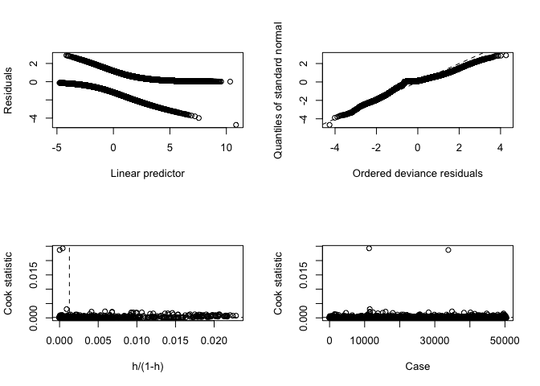

```r
#Question 4:
library(boot)
q =glm.diag.plots(new_myglm_second,
                  glmdiag = glm.diag(new_myglm_second),
                  labels=NULL)
```

```r
q
```

# Question 5:

P: positive samples  
N: negative samples  
TP: true positive TP (eqv. with hit)  
TN: true negative (eqv. with correct rejection)  
FP: false positive (eqv. with false alarm, Type I error)  
FN: false negative (eqv. with miss, Type II error)  
Accuracy (ACC) ACC = (TP+TN)/(P+T)  
False positive rate (FPR): 1- TN/N  
True positive rate (TPR): TP/P

```r
#HW 07:
#Question 5:
library(dplyr)
library(data.table)
```

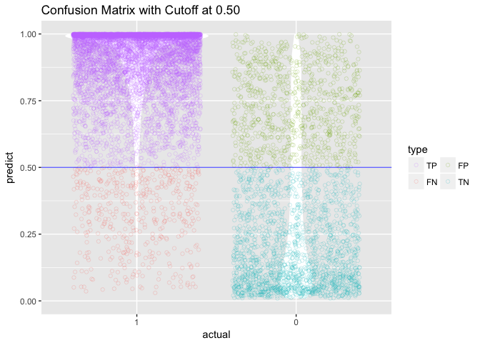

```r
#----------------
# 80 percent for train and 20 percent for Test:
Train <- sample_frac(murder_suicide_levels,
                     size = 0.8,
                     replace =FALSE)
sid<-as.numeric(rownames(Train))
Test<-murder_suicide_levels[-sid,]

#----------------
#Train our model:
new_myglm_second_train = glm(data = Train,
                Suicide ~ `Age`+
                  `ResidentStatus=2` +
                  `ResidentStatus=3` + `Sex=F` +
                  `Education2003Revision=1` +
                  `Education2003Revision=2` +
                  `Education2003Revision=3` +
                  `Education2003Revision=6` +
                  `Education2003Revision=7` +
                  `Autopsy=N`+
                  `PlaceOfDeathAndDecedentsStatus=1` +
                  `PlaceOfDeathAndDecedentsStatus=2` +
                  `PlaceOfDeathAndDecedentsStatus=3` +
                  `PlaceOfDeathAndDecedentsStatus=4` +
                  `PlaceOfDeathAndDecedentsStatus=5` +
                  `PlaceOfDeathAndDecedentsStatus=6` +
                  `MaritalStatus=M` + `InjuryAtWork=N` +
                  `MonthOfDeath=4` + `MonthOfDeath=2`+
                  `DayOfWeekOfDeath=5`+ `DayOfWeekOfDeath=4` +`DayOfWeekOfDeath=3`+ `DayOfWeekOfDeath=2`+
                  `MethodOfDisposition=C` + `Autopsy=N` +
                  `PlaceOfInjury=1` +
                  `PlaceOfInjury=4` +
                  `PlaceOfInjury=6` + `Race=2`  + `NumberOfEntityAxisConditions`+
                  `NumberOfRecordAxisConditions`,
                  family = binomial(link = 'logit'))

#----------------
#Predicting:
new_predict = predict(new_myglm_second_train,Test,type="response" )
#----------------
#Combining:
Test %>%
  mutate(Predicted =new_predict ) -> Test
#----------------
#Using the function:
ConfusionMatrixInfo <- function( data, predict, actual, cutoff )
{
  # extract the column ;
  # relevel making 1 appears on the more commonly seen position in
  # a two by two confusion matrix
  predict <- data[[predict]]
  actual  <- relevel( as.factor(data[[actual]]), "1")
  result <- data.table( actual = actual, predict = predict )

  # caculating each pred falls into which category for the confusion matrix
  result[ , type := ifelse( predict >= cutoff & actual == 1, "TP",
                            ifelse( predict >= cutoff & actual == 0, "FP",
                                    ifelse( predict <  cutoff & actual == 1, "FN", "TN" ) ) ) %>% as.factor() ]

  # jittering : can spread the points along the x axis
  plot <- ggplot( result, aes( actual, predict, color = type ) ) +
    geom_violin( fill = "white", color = NA ) +
    geom_jitter( shape = 1 , alpha = 0.2) +
    geom_hline( yintercept = cutoff, color = "blue", alpha = 0.6 ) +
    scale_y_continuous( limits = c( 0, 1 ) ) +
    scale_color_discrete( breaks = c( "TP", "FN", "FP", "TN" ) ) + # ordering of the legend
    guides( col = guide_legend( nrow = 2 ) ) + # adjust the legend to have two rows
    ggtitle( sprintf( "Confusion Matrix with Cutoff at %.2f", cutoff ) )

  return( list( data = result, plot = plot ) )
}
#----------------
#CM:
Test <- as.data.frame(Test)

cm_info = ConfusionMatrixInfo( data = Test, predict = "Predicted",
                               actual = "Suicide", cutoff = .5 )

cm_info$plot
```

```r
#----------------
temp = cm_info$data
#We will use the given definitions to find the values:
TP = sum(temp$type == "TP")
TN = sum(temp$type == "TN")
FP = sum(temp$type == "FP")
FN = sum(temp$type == "FN")
n = nrow(Test)
ACC = (TP+TN)/n
N = TN+FN

FPR = FP/N
TPR = TP/N
P = TP+FP

TP
```

```
## [1] 6955
```

```r
TN
```

```
## [1] 1779
```

```r
FP
```

```
## [1] 879
```

```r
FN
```

```
## [1] 449
```

```r
ACC
```

```
## [1] 0.8680183
```

```r
FPR
```

```
## [1] 0.3945242
```

```r
TPR
```

```
## [1] 3.121634
```

```r
P
```

```
## [1] 7834
```

```r
N
```

```
## [1] 2228
```

```r
#----------------
```

## Question 6:

Using our definition of accuracy we will have this:

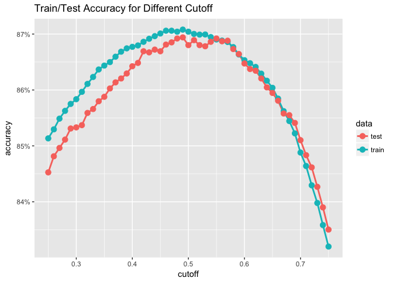

```r
library(ROCR)
library(grid)
library(caret)
library(dplyr)
library(scales)
library(ggplot2)
library(gridExtra)
library(data.table)
library(tidyr)
library(e1071)
#----------------
# Our function:
AccuracyCutoffInfo <- function( train, test, predict, actual )
{
  # change the cutoff value's range as you please
  cutoff <- seq( .25, .75, by = .01 )


  accuracy <- lapply( cutoff, function(c)
  {
    r1= as.factor( train[[predict]] > c )
    levels(r1) = c("0","1")
    r2= as.factor( test[[predict]] > c )
    levels(r2) = c("0","1")
    # use the confusionMatrix from the caret package
    cm_train <- confusionMatrix(r1, as.factor(train[[actual]]) )
    cm_test  <- confusionMatrix(r2, as.factor(test[[actual]])  )

    dt <- data.table( cutoff = c,
                      train  = cm_train$overall[["Accuracy"]],
                      test   = cm_test$overall[["Accuracy"]] )
    return(dt)
  }) %>% rbindlist()

  # visualize the accuracy of the train and test set for different cutoff value
  # accuracy in percentage.
  accuracy_long <- gather( accuracy, "data", "accuracy", -1 )

  plot <- ggplot( accuracy_long, aes( cutoff, accuracy, group = data, color = data ) ) +
    geom_line( size = 1 ) + geom_point( size = 3 ) +
    scale_y_continuous( label = percent ) +
    ggtitle( "Train/Test Accuracy for Different Cutoff" )

  return( list( data = accuracy, plot = plot ) )
}
#----------------
#Prediction for train dataset:
acc_predicted = predict(new_myglm_second , Train , type="response")
Train$Predicted = acc_predicted

#----------------
#Finding accuracy:

accuracy_new = AccuracyCutoffInfo( train = Train,
                                   test = Test,
                                   predict = "Predicted",
                                   actual = "Suicide" )
#Plotting:
accuracy_new$plot
```

```r
#----------------
#Cuttoff for train:
temp_data = accuracy_new$data
max_train =max(temp_data[,2])
index_train =which(temp_data[,2]==max_train)
cutt_off_train = temp_data[index_train,1]
cutt_off_train
```

```
##    cutoff
## 1:   0.49
```

```r
#Cuttoff for Test:
max_test =max(temp_data[,3])
index_test =which(temp_data[,3]==max_test)
cutt_off_test = temp_data[index_test,1]
cutt_off_test
```

```
##    cutoff
## 1:   0.49
```

```r
#----------------
```

## Question 7:

We will find the ROC curve as given with this function:

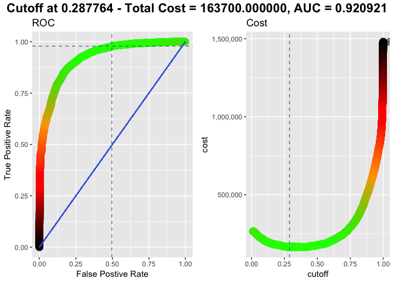

```r
#----------------
# Our function:

ROCInfo <- function( data, predict, actual, cost.fp, cost.fn )
{
  # calculate the values using the ROCR library
  # true positive, false postive
  pred <- prediction( data[[predict]], data[[actual]] )
  perf <- performance( pred, "tpr", "fpr" )
  roc_dt <- data.frame( fpr = perf@x.values[[1]], tpr = perf@y.values[[1]] )

  # cost with the specified false positive and false negative cost
  # false postive rate * number of negative instances * false positive cost +
  # false negative rate * number of positive instances * false negative cost
  cost <- perf@x.values[[1]] * cost.fp * sum( data[[actual]] == 0 ) +
    ( 1 - perf@y.values[[1]] ) * cost.fn * sum( data[[actual]] == 1 )

  cost_dt <- data.frame( cutoff = pred@cutoffs[[1]], cost = cost )

  # optimal cutoff value, and the corresponding true positive and false positive rate
  best_index  <- which.min(cost)
  best_cost   <- cost_dt[ best_index, "cost" ]
  best_tpr    <- roc_dt[ best_index, "tpr" ]
  best_fpr    <- roc_dt[ best_index, "fpr" ]
  best_cutoff <- pred@cutoffs[[1]][ best_index ]

  # area under the curve
  auc <- performance( pred, "auc" )@y.values[[1]]

  # normalize the cost to assign colors to 1
  normalize <- function(v) ( v - min(v) ) / diff( range(v) )

  # create color from a palette to assign to the 100 generated threshold between 0 ~ 1
  # then normalize each cost and assign colors to it, the higher the blacker
  # don't times it by 100, there will be 0 in the vector
  col_ramp <- colorRampPalette( c( "green", "orange", "red", "black" ) )(100)
  col_by_cost <- col_ramp[ ceiling( normalize(cost) * 99 ) + 1 ]

  roc_plot <- ggplot( roc_dt, aes( fpr, tpr ) ) +
    geom_line( color = rgb( 0, 0, 1, alpha = 0.3 ) ) +
    geom_point( color = col_by_cost, size = 4, alpha = 0.2 ) +
    geom_segment( aes( x = 0, y = 0, xend = 1, yend = 1 ), alpha = 0.8, color = "royalblue" ) +
    labs( title = "ROC", x = "False Postive Rate", y = "True Positive Rate" ) +
    geom_hline( yintercept = best_tpr, alpha = 0.8, linetype = "dashed", color = "steelblue4" ) +
    geom_vline( xintercept = best_fpr, alpha = 0.8, linetype = "dashed", color = "steelblue4" )

  cost_plot <- ggplot( cost_dt, aes( cutoff, cost ) ) +
    geom_line( color = "blue", alpha = 0.5 ) +
    geom_point( color = col_by_cost, size = 4, alpha = 0.5 ) +
    ggtitle( "Cost" ) +
    scale_y_continuous( labels = comma ) +
    geom_vline( xintercept = best_cutoff, alpha = 0.8, linetype = "dashed", color = "steelblue4" )

  # the main title for the two arranged plot
  sub_title <- sprintf( "Cutoff at %f - Total Cost = %f, AUC = %f",
                        best_cutoff, best_cost, auc )

  # arranged into a side by side plot
  plot <- arrangeGrob( roc_plot, cost_plot, ncol = 2,
                       top = textGrob( sub_title, gp = gpar( fontsize = 16, fontface = "bold" ) ) )

  return( list( plot          = plot,
                cutoff    = best_cutoff,
                totalcost   = best_cost,
                auc         = auc,
                sensitivity = best_tpr,
                specificity = 1 - best_fpr ) )
}

#----------------
# We assume that FN costs more than FP:
cost_fp = 100
cost_fn = 200
roc_info = ROCInfo( data = cm_info$data , predict = "predict",
                    actual = "actual", cost.fp = cost_fp, cost.fn = cost_fn )
grid.draw(roc_info$plot)
```